# Data607_Assignment_1

Shaya Engelman

2023-09-04

## The rising age of Congress members

https://fivethirtyeight.com/features/aging-congress-boomers/:

```r
#Let's shorten this table by averaging the age of the entire Congress per session
aging_congress <- read.csv("https://raw.githubusercontent.com/fivethirtyeight/data/master/congress-demographics/data_aging_congress.csv")
aging_congress_subset <- aging_congress[c(1,3,11,12)]
glimpse(aging_congress_subset)
```

```
## Rows: 29,120
## Columns: 4
## $ congress  <int> 82, 80, 81, 82, 83, 84, 85, 86, 87, 88, 89, 90, 91, 92, 93, …
## $ chamber   <chr> "House", "House", "House", "House", "House", "House", "House…
## $ age_days  <int> 19626, 14106, 14837, 15567, 16298, 17028, 17759, 18489, 1922…
## $ age_years <dbl> 53.73306, 38.62012, 40.62149, 42.62012, 44.62149, 46.62012, …
```

The code above gives us the dimensions of the large dataset. That dataset is extremely large and is not easily read. However, using the dplyr :: glimpse function we can see it’s dimensions. We can see it has 4 columns and 29,120 rows. Those columns represent the number Congress they served in, the specific chamber of Congress they were part of, the age they were at the time in days and, finally, the age they were in years. The rows are all the different congressmen collected.

Since the above dataset is too large to print and easily read, we can try making a smaller table to help us be able to take a look at this data.

```r
average_age_congress <- aggregate(age_years ~ congress, aging_congress_subset, mean)
kable(average_age_congress,
      row.names = TRUE,
      col.names = c("# Congress", "Average Age"),
      table.attr = "style='width:30%;'")
```

|  | # Congress | Average Age |
| --- | --- | --- |
| 1 | 66 | 51.73002 |
| 2 | 67 | 52.60360 |
| 3 | 68 | 52.56625 |
| 4 | 69 | 53.22577 |
| 5 | 70 | 53.95525 |
| 6 | 71 | 54.61430 |
| 7 | 72 | 54.39717 |
| 8 | 73 | 53.45225 |
| 9 | 74 | 52.60445 |
| 10 | 75 | 52.50597 |
| 11 | 76 | 52.34120 |
| 12 | 77 | 52.40562 |
| 13 | 78 | 53.15972 |
| 14 | 79 | 53.51016 |
| 15 | 80 | 52.59263 |
| 16 | 81 | 52.69689 |
| 17 | 82 | 53.24015 |
| 18 | 83 | 53.19028 |
| 19 | 84 | 53.39559 |
| 20 | 85 | 54.19333 |
| 21 | 86 | 53.16789 |
| 22 | 87 | 53.60106 |
| 23 | 88 | 52.95704 |
| 24 | 89 | 52.20452 |
| 25 | 90 | 52.43809 |
| 26 | 91 | 52.71952 |
| 27 | 92 | 53.07843 |
| 28 | 93 | 52.40800 |
| 29 | 94 | 51.28931 |
| 30 | 95 | 50.60187 |
| 31 | 96 | 50.00601 |
| 32 | 97 | 49.51691 |
| 33 | 98 | 50.02744 |
| 34 | 99 | 51.04766 |
| 35 | 100 | 51.84557 |
| 36 | 101 | 52.66166 |
| 37 | 102 | 53.81787 |
| 38 | 103 | 52.92735 |
| 39 | 104 | 52.68546 |
| 40 | 105 | 53.07348 |
| 41 | 106 | 54.13965 |
| 42 | 107 | 54.71521 |
| 43 | 108 | 55.43003 |
| 44 | 109 | 56.51792 |
| 45 | 110 | 57.29550 |
| 46 | 111 | 57.79102 |
| 47 | 112 | 57.63021 |
| 48 | 113 | 57.52962 |
| 49 | 114 | 57.89433 |
| 50 | 115 | 58.77052 |
| 51 | 116 | 58.43788 |
| 52 | 117 | 58.83102 |
| 53 | 118 | 58.55512 |

```r
subset_average <- average_age_congress %>% slice(which(row_number() %% 3 == 1))

kable(subset_average,
      row.names = TRUE,
      col.names = c("# Congress", "Average Age"),
      table.attr = "style='width:30%;'")
```

|  | # Congress | Average Age |
| --- | --- | --- |
| 1 | 66 | 51.73002 |
| 2 | 69 | 53.22577 |
| 3 | 72 | 54.39717 |
| 4 | 75 | 52.50597 |
| 5 | 78 | 53.15972 |
| 6 | 81 | 52.69689 |
| 7 | 84 | 53.39559 |
| 8 | 87 | 53.60106 |
| 9 | 90 | 52.43809 |
| 10 | 93 | 52.40800 |
| 11 | 96 | 50.00601 |
| 12 | 99 | 51.04766 |
| 13 | 102 | 53.81787 |
| 14 | 105 | 53.07348 |
| 15 | 108 | 55.43003 |
| 16 | 111 | 57.79102 |
| 17 | 114 | 57.89433 |
| 18 | 117 | 58.83102 |

We can now plot both those tables to see if their trend is the same or if we lost too much by trimming this data.

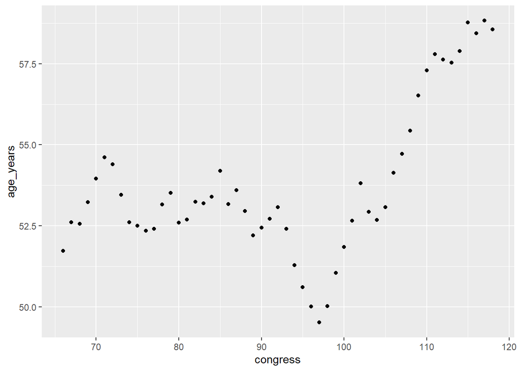

```r
#we can plot these tables to see their trend
ggplot(data = average_age_congress, mapping = aes(x = congress, y = age_years)) +
  geom_point()
```

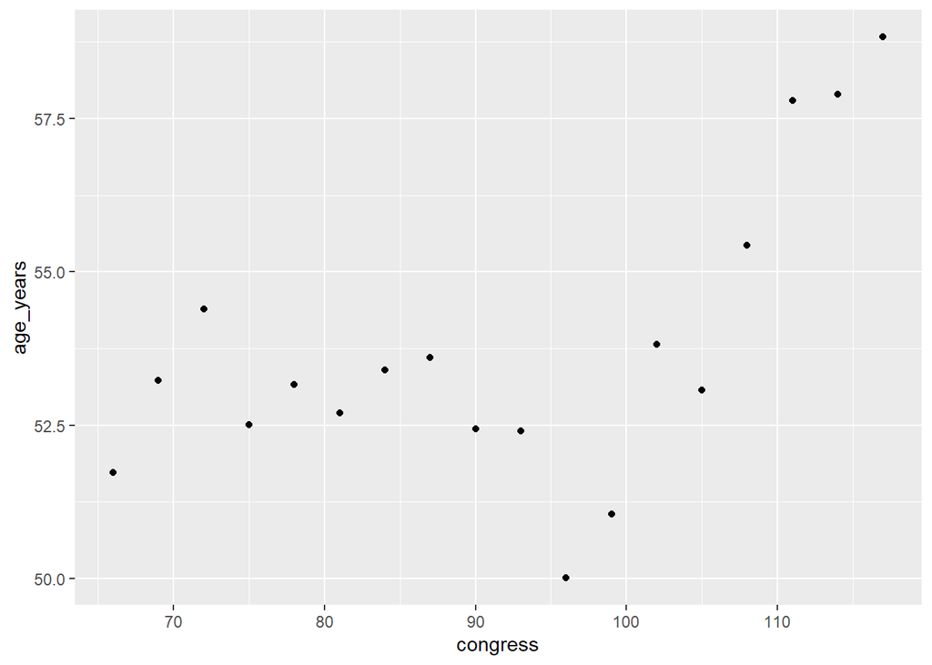

```r
ggplot(data = subset_average, mapping = aes(x = congress, y = age_years)) +
  geom_point()
```

Using the above tables and plots we can easily see that while at the beginning of the collected data the average age of Congress stayed within a certain range, recently that number has been rising fast. This can be due to a variety of reasons but is likely due to the huge population jump during the Boomer generation. Assuming this is indeed a major contributing factor, we can expect this number to come down as the Boomer generation loses their impact on the vote.

The ramifications of an older Congress can be quite large. We live in a world evolving very at a very rapid pace. Older people typically have a lower understanding of new technology. As those new technologies become a bigger part of our lives, we would prefer the people representing us in government would understand them.

Sources:

[data/congress-demographics at master · fivethirtyeight/data (github.com)](https://github.com/fivethirtyeight/data/tree/master/congress-demographics)